# E-Commerce Delivery Time Prediction

### Context

An international e-commerce company based wants to discover key insights from their customer database. They want to use some of the most advanced machine learning techniques to study their customers. The company sells electronic products.

### Content

The dataset used for model building contained 10999 observations of 12 variables. The data contains the following information:

- ID: ID Number of Customers.
- Warehouse block: The Company have big Warehouse which is divided in to block such as A,B,C,D,E.
- Mode of shipment:The Company Ships the products in multiple way such as Ship, Flight and Road.
- Customer care calls: The number of calls made from enquiry for enquiry of the shipment.
- Customer rating: The company has rated from every customer. 1 is the lowest (Worst), 5 is the highest (Best).
- Cost of the product: Cost of the Product in US Dollars.
- Prior purchases: The Number of Prior Purchase.
- Product importance: The company has categorized the product in the various parameter such as low, medium, high.
- Gender: Male and Female.
- Discount offered: Discount offered on that specific product.
- Weight in gms: It is the weight in grams.
- Reached on time: It is the target variable, where 1 Indicates that the product has NOT reached on time and 0 indicates it has reached on time.

```python
import warnings
warnings.filterwarnings('ignore')
```

```python
import pandas as pd
import numpy as np
import seaborn as sns
import matplotlib.pyplot as plt

%matplotlib inline
```

```python
df = pd.read_csv("Train.csv")
```

```python
df.head()
```

|  | ID | Warehouse_block | Mode_of_Shipment | Customer_care_calls | Customer_rating | Cost_of_the_Product | Prior_purchases | Product_importance | Gender | Discount_offered | Weight_in_gms | Reached.on.Time_Y.N |
| --- | --- | --- | --- | --- | --- | --- | --- | --- | --- | --- | --- | --- |
| 0 | 1 | D | Flight | 4 | 2 | 177 | 3 | low | F | 44 | 1233 | 1 |
| 1 | 2 | F | Flight | 4 | 5 | 216 | 2 | low | M | 59 | 3088 | 1 |
| 2 | 3 | A | Flight | 2 | 2 | 183 | 4 | low | M | 48 | 3374 | 1 |
| 3 | 4 | B | Flight | 3 | 3 | 176 | 4 | medium | M | 10 | 1177 | 1 |
| 4 | 5 | C | Flight | 2 | 2 | 184 | 3 | medium | F | 46 | 2484 | 1 |

#### Checking Dataset Columns

```python
df.columns
```

```
Index(['ID', 'Warehouse_block', 'Mode_of_Shipment', 'Customer_care_calls',
       'Customer_rating', 'Cost_of_the_Product', 'Prior_purchases',
       'Product_importance', 'Gender', 'Discount_offered', 'Weight_in_gms',
       'Reached.on.Time_Y.N'],
      dtype='object')
```

#### Checking Dataset Shape

```python
df.shape
```

```
(10999, 12)
```

#### Check Null Values in the Dataset

```python
df.isna().sum()
```

```
ID                     0
Warehouse_block        0
Mode_of_Shipment       0
Customer_care_calls    0
Customer_rating        0
Cost_of_the_Product    0
Prior_purchases        0
Product_importance     0
Gender                 0
Discount_offered       0
Weight_in_gms          0
Reached.on.Time_Y.N    0
dtype: int64
```

As we can see there are no null values in the dataset. So we need not deal with the Null values

#### Checking Datatypes of Dataset

```python
df.dtypes
```

```
ID                      int64
Warehouse_block        object
Mode_of_Shipment       object
Customer_care_calls     int64
Customer_rating         int64
Cost_of_the_Product     int64
Prior_purchases         int64
Product_importance     object
Gender                 object
Discount_offered        int64
Weight_in_gms           int64
Reached.on.Time_Y.N     int64
dtype: object
```

### Exploratory Data Analysis

```python
df.head(1)
```

|  | ID | Warehouse_block | Mode_of_Shipment | Customer_care_calls | Customer_rating | Cost_of_the_Product | Prior_purchases | Product_importance | Gender | Discount_offered | Weight_in_gms | Reached.on.Time_Y.N |
| --- | --- | --- | --- | --- | --- | --- | --- | --- | --- | --- | --- | --- |
| 0 | 1 | D | Flight | 4 | 2 | 177 | 3 | low | F | 44 | 1233 | 1 |

#### Handling ID column

```python
df.ID.tail(1)
```

```
10998    10999
Name: ID, dtype: int64
```

It looks like we can drop the ID columns as it is just a row number

```python
df = df.drop('ID', axis=1)
```

Let us check the target column

#### Checking the Output Values

```python
df['Reached.on.Time_Y.N'].value_counts()
```

```
1    6563
0    4436
Name: Reached.on.Time_Y.N, dtype: int64
```

Let us check if the dataset is balanced or not. Based on that we can make the splits to make the model building better.

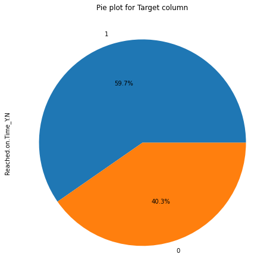

```
Percentage of Data having 1 as Output: 59.67%
Percentage of Data having 0 as Output: 40.33%
Difference: 19.34%
```

```python
value_1 = len(df[df['Reached.on.Time_Y.N'] == 1])/len(df)*100
value_0 = len(df[df['Reached.on.Time_Y.N'] == 0])/len(df)*100

plt.figure(figsize=(8,8))
df['Reached.on.Time_Y.N'].value_counts().plot(kind='pie', autopct = '%1.1f%%')
plt.title("Pie plot for Target column")
plt.show()

print("Percentage of Data having 1 as Output: {:.2f}%".format(value_1))
print("Percentage of Data having 0 as Output: {:.2f}%".format(value_0))

print('Difference: {:.2f}%'.format(value_1-value_0))
```

We can see that Data with Output value 1 is 19.34% more than the Data with Output value 0. It is a bit unbalanced but not very much unblalanced as we can see that we 40% data with Output values as 0.  
Anyway we can do shuttle split while splitting the data to avoid as biased splitting of data

```python
df['Warehouse_block'].value_counts()
```

```
F    3666
D    1834
A    1833
B    1833
C    1833
Name: Warehouse_block, dtype: int64
```

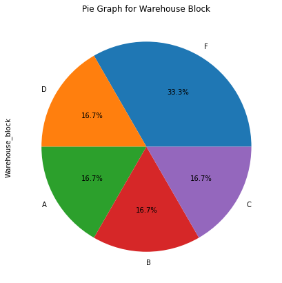

```python
plt.figure(figsize=(7,7))
df['Warehouse_block'].value_counts().plot(kind='pie',  autopct='%1.1f%%')
plt.title("Pie Graph for Warehouse Block")
plt.show()
```

As we can see from the graph there are more products that were stored in Warehouse Block F followed by rest of the block with a very margin difference.

```python
df['Mode_of_Shipment'].value_counts()
```

```
Ship      7462
Flight    1777
Road      1760
Name: Mode_of_Shipment, dtype: int64
```

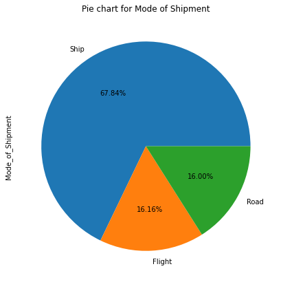

```python
plt.figure(figsize=(7,7))
df['Mode_of_Shipment'].value_counts().plot(kind='pie', autopct = "%1.2f%%")
plt.title("Pie chart for Mode of Shipment")
plt.show()
```

We can see from the Pie graph that more than half of the shipment is through ship.

```python
df['Product_importance'].value_counts()
```

```
low       5297
medium    4754
high       948
Name: Product_importance, dtype: int64
```

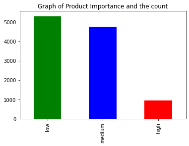

```python
df['Product_importance'].value_counts().plot(kind='bar', color=['g', 'b', 'r'])
plt.title("Graph of Product Importance and the count")
plt.show()
```

We can see that there are very less number of products that have high importance where are more number of products are under Low and Medium importance.

```python
df['Gender'].value_counts()
```

```
F    5545
M    5454
Name: Gender, dtype: int64
```

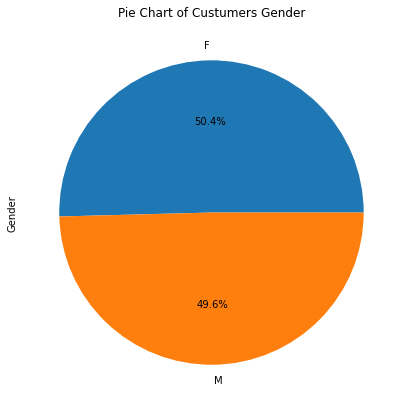

```python
plt.figure(figsize=(7,7))
df.Gender.value_counts().plot(kind='pie', autopct='%1.1f%%')
plt.title('Pie Chart of Custumers Gender')
plt.show()
```

We can see from the Pie chart that Male and Female Customers are almost equal to each other in the Dataset.

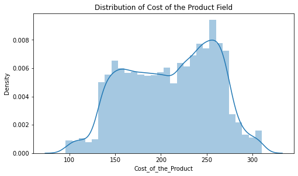

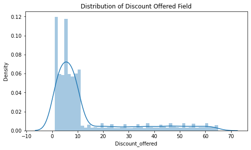

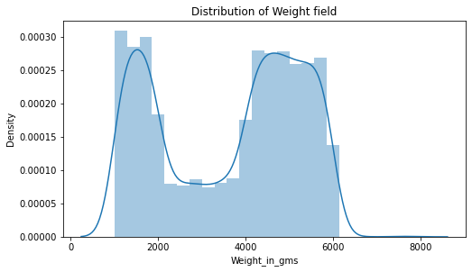

```python
plt.figure(figsize=(8,15))
plt.subplot(3,1,1)
sns.distplot(df.Cost_of_the_Product)
plt.title("Distribution of Cost of the Product Field")
plt.show()

plt.figure(figsize=(8,15))
plt.subplot(3,1,2)
sns.distplot(df.Discount_offered)
plt.title("Distribution of Discount Offered Field")
plt.show()

plt.figure(figsize=(8,15))
plt.subplot(3,1,3)
sns.distplot(df.Weight_in_gms)
plt.title('Distribution of Weight field')
plt.show()
```

**Cost of the Product**

- As we can see from the histogram that Cost of the Product in the Data set is ranging from 100 to 300 and it is more skewwing towards the left side in the graph.

**Discount Offered**

- We can clearly that graph is completely skewwing towards the right side which mean it is Positively skewwed graph.

**Weight in Grams**

- In this we can actually see sort of two Normally distributed curves but the second is more skewwed towards the right side of the graph

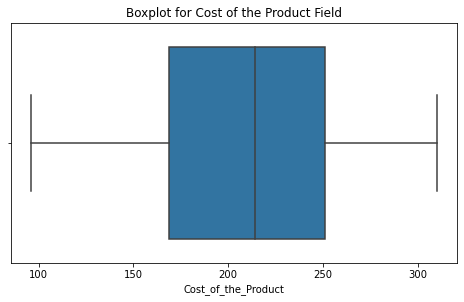

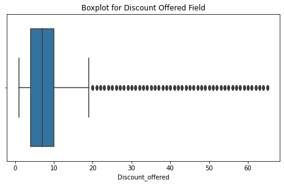

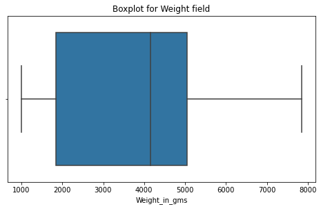

```python
plt.figure(figsize=(8,15))
plt.subplot(3,1,1)
sns.boxplot(df.Cost_of_the_Product)
plt.title("Boxplot for Cost of the Product Field")
plt.show()

plt.figure(figsize=(8,15))
plt.subplot(3,1,2)
sns.boxplot(df.Discount_offered)
plt.title("Boxplot for Discount Offered Field")
plt.show()

plt.figure(figsize=(8,15))
plt.subplot(3,1,3)
sns.boxplot(df.Weight_in_gms)
plt.title('Boxplot for Weight field')
plt.show()
```

We can see that there are no outliers for Cost of the Product and Weight of the Product but we can clearly see some outliers for the Discount Offered field. As we cannot replace them with any other values we are continouing with the same

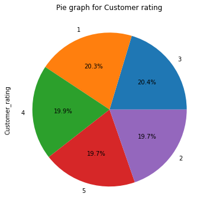

```python
plt.figure(figsize=(6,6))
df['Customer_rating'].value_counts().plot(kind='pie', autopct = '%1.1f%%')
plt.title('Pie graph for Customer rating')
plt.show()
```

We can see that all the rating are equally distributed.

#### BiVariate Analysis

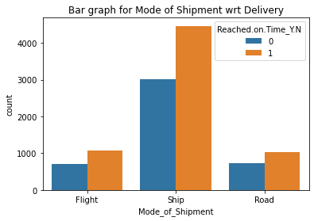

```python
sns.countplot(df.Mode_of_Shipment, hue = df['Reached.on.Time_Y.N'])
plt.title('Bar graph for Mode of Shipment wrt Delivery')
plt.show()
```

We can see that as per the Data set, 1 indicates that product was not reached on time and 0 indicates that the product reached on time. So based on the graph we can say that There are more products that were not reached on time.

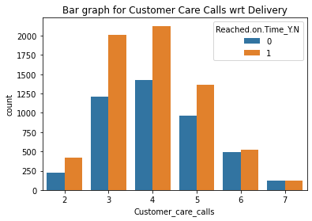

```python
sns.countplot(df.Customer_care_calls, hue = df['Reached.on.Time_Y.N'])
plt.title('Bar graph for Customer Care Calls wrt Delivery')
plt.show()
```

Based on the graph we can see that people who have called the customer care more times have tendency to receive their order delivered on time.

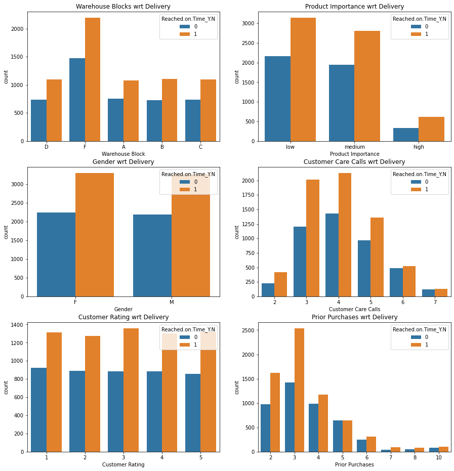

```python
plt.figure(figsize=(15,16))

plt.subplot(3, 2, 1)
sns.countplot(data=df, x='Warehouse_block', hue='Reached.on.Time_Y.N')
plt.xlabel('Warehouse Block')
plt.title("Warehouse Blocks wrt Delivery")

plt.subplot(3, 2, 2)
sns.countplot(data=df, x='Product_importance', hue='Reached.on.Time_Y.N')
plt.xlabel('Product Importance')
plt.title("Product Importance wrt Delivery")

plt.subplot(3, 2, 3)
sns.countplot(data=df, x='Gender', hue='Reached.on.Time_Y.N')
plt.xlabel('Gender')
plt.title("Gender wrt Delivery")

plt.subplot(3, 2, 4)
sns.countplot(data=df, x='Customer_care_calls', hue='Reached.on.Time_Y.N')
plt.xlabel('Customer Care Calls')
plt.title("Customer Care Calls wrt Delivery")

plt.subplot(3, 2, 5)
sns.countplot(data=df, x='Customer_rating', hue='Reached.on.Time_Y.N')
plt.xlabel('Customer Rating')
plt.title("Customer Rating wrt Delivery")

plt.subplot(3, 2, 6)
sns.countplot(data=df, x='Prior_purchases', hue='Reached.on.Time_Y.N')
plt.xlabel('Prior Purchases')
plt.title("Prior Purchases wrt Delivery")

plt.show()
```

```
Percentage of Products with discount less than 10: 75.93%
```

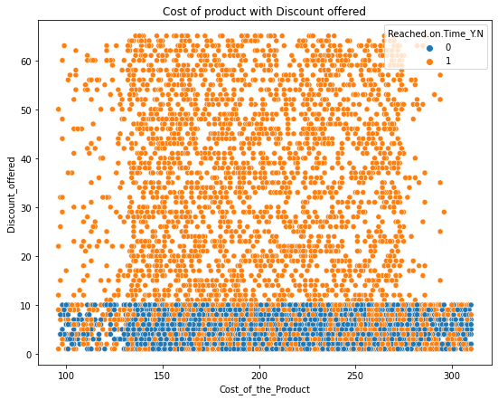

```python
print("Percentage of Products with discount less than 10: {:.2f}%".format(len(df[df['Discount_offered'] <= 10])/len(df)*100))

plt.figure(figsize=(9,7))
sns.scatterplot(data = df, x='Cost_of_the_Product', y='Discount_offered', hue='Reached.on.Time_Y.N')
plt.title('Cost of product with Discount offered')
plt.show()
```

This is a very good insight as we can see that Products having discount less that 10% is tend to get delivered on time than the products having discount more than 10%.

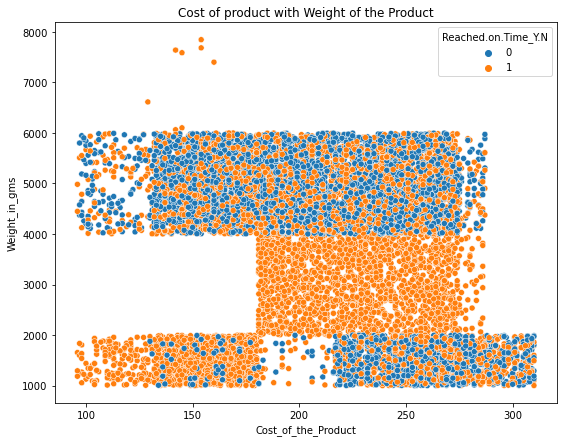

```python
plt.figure(figsize=(9,7))
sns.scatterplot(data = df, x='Cost_of_the_Product', y='Weight_in_gms', hue='Reached.on.Time_Y.N')
plt.title('Cost of product with Weight of the Product')
plt.show()
```

```python
a = (len(df[df['Weight_in_gms'] >= 4000]) + len(df[df['Weight_in_gms'] <= 2000]))/len(df)*100

print("We can see from the graph that Products with orders between 4000 to 6000 grams and products weighing below 2000 grams are        getting deliver on time")

print("The percentage of product under these weight categories are: {:.2f}%".format(a))
```

```
We can see from the graph that Products with orders between 4000 to 6000 grams and products weighing below 2000 grams are        getting deliver on time
The percentage of product under these weight categories are: 83.76%
```

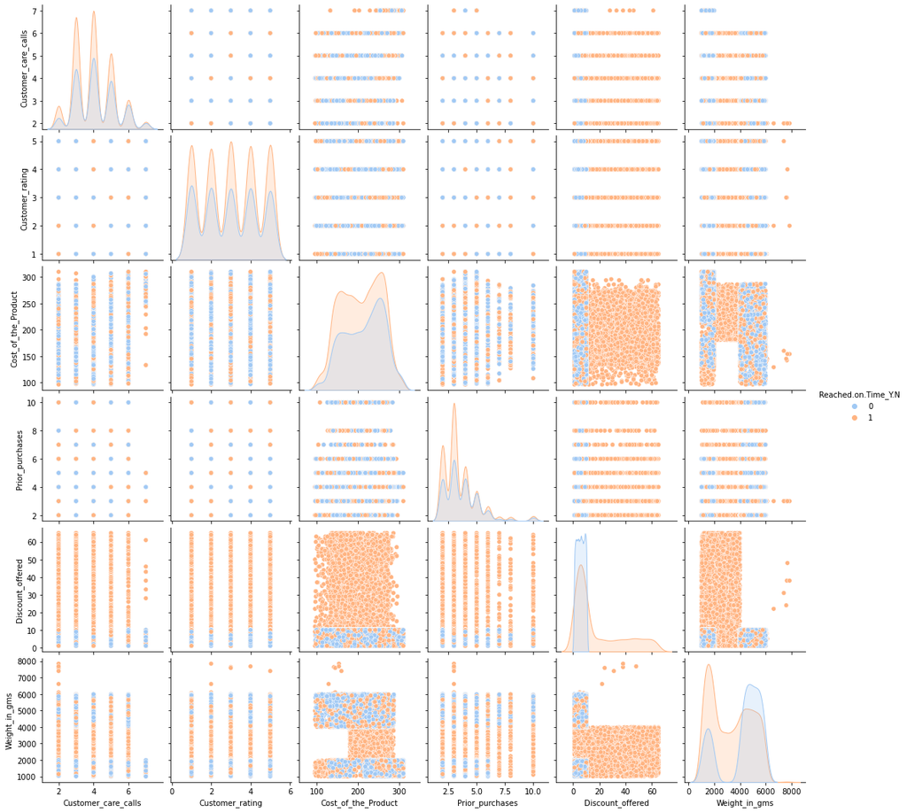

```python
sns.pairplot(df, diag_kind='kde', hue='Reached.on.Time_Y.N', palette='pastel')
plt.show()
```

#### One Hot Encoding

```python
cols = df[df.columns[df.dtypes == 'object']]
```

```python
df1 = pd.get_dummies(cols, drop_first = True)
```

```python
df1.head()
```

|  | Warehouse_block_B | Warehouse_block_C | Warehouse_block_D | Warehouse_block_F | Mode_of_Shipment_Road | Mode_of_Shipment_Ship | Product_importance_low | Product_importance_medium | Gender_M |
| --- | --- | --- | --- | --- | --- | --- | --- | --- | --- |
| 0 | 0 | 0 | 1 | 0 | 0 | 0 | 1 | 0 | 0 |
| 1 | 0 | 0 | 0 | 1 | 0 | 0 | 1 | 0 | 1 |
| 2 | 0 | 0 | 0 | 0 | 0 | 0 | 1 | 0 | 1 |
| 3 | 1 | 0 | 0 | 0 | 0 | 0 | 0 | 1 | 1 |
| 4 | 0 | 1 | 0 | 0 | 0 | 0 | 0 | 1 | 0 |

```python
df = pd.concat([df,df1], axis=1)
```

```python
df.head()
```

|  | Warehouse_block | Mode_of_Shipment | Customer_care_calls | Customer_rating | Cost_of_the_Product | Prior_purchases | Product_importance | Gender | Discount_offered | Weight_in_gms | Reached.on.Time_Y.N | Warehouse_block_B | Warehouse_block_C | Warehouse_block_D | Warehouse_block_F | Mode_of_Shipment_Road | Mode_of_Shipment_Ship | Product_importance_low | Product_importance_medium | Gender_M |
| --- | --- | --- | --- | --- | --- | --- | --- | --- | --- | --- | --- | --- | --- | --- | --- | --- | --- | --- | --- | --- |
| 0 | D | Flight | 4 | 2 | 177 | 3 | low | F | 44 | 1233 | 1 | 0 | 0 | 1 | 0 | 0 | 0 | 1 | 0 | 0 |
| 1 | F | Flight | 4 | 5 | 216 | 2 | low | M | 59 | 3088 | 1 | 0 | 0 | 0 | 1 | 0 | 0 | 1 | 0 | 1 |
| 2 | A | Flight | 2 | 2 | 183 | 4 | low | M | 48 | 3374 | 1 | 0 | 0 | 0 | 0 | 0 | 0 | 1 | 0 | 1 |
| 3 | B | Flight | 3 | 3 | 176 | 4 | medium | M | 10 | 1177 | 1 | 1 | 0 | 0 | 0 | 0 | 0 | 0 | 1 | 1 |
| 4 | C | Flight | 2 | 2 | 184 | 3 | medium | F | 46 | 2484 | 1 | 0 | 1 | 0 | 0 | 0 | 0 | 0 | 1 | 0 |

```python
df = df.drop(['Warehouse_block', 'Mode_of_Shipment', 'Product_importance', 'Gender'], axis=1)
```

```python
df.dtypes
```

```
Customer_care_calls          int64
Customer_rating              int64
Cost_of_the_Product          int64
Prior_purchases              int64
Discount_offered             int64
Weight_in_gms                int64
Reached.on.Time_Y.N          int64
Warehouse_block_B            uint8
Warehouse_block_C            uint8
Warehouse_block_D            uint8
Warehouse_block_F            uint8
Mode_of_Shipment_Road        uint8
Mode_of_Shipment_Ship        uint8
Product_importance_low       uint8
Product_importance_medium    uint8
Gender_M                     uint8
dtype: object
```

```python
df.corr()
```

|  | Customer_care_calls | Customer_rating | Cost_of_the_Product | Prior_purchases | Discount_offered | Weight_in_gms | Reached.on.Time_Y.N | Warehouse_block_B | Warehouse_block_C | Warehouse_block_D | Warehouse_block_F | Mode_of_Shipment_Road | Mode_of_Shipment_Ship | Product_importance_low | Product_importance_medium | Gender_M |
| --- | --- | --- | --- | --- | --- | --- | --- | --- | --- | --- | --- | --- | --- | --- | --- | --- |
| Customer_care_calls | 1.000000 | 0.012209 | 0.323182 | 0.180771 | -0.130750 | -0.276615 | -0.067126 | -0.013428 | 0.004099 | -0.000401 | 0.012732 | 0.003292 | -0.017629 | 0.047111 | -0.019761 | 0.002545 |
| Customer_rating | 0.012209 | 1.000000 | 0.009270 | 0.013179 | -0.003124 | -0.001897 | 0.013119 | -0.003222 | 0.001093 | 0.008687 | 0.003092 | 0.001516 | 0.000765 | -0.004752 | 0.004408 | 0.002775 |
| Cost_of_the_Product | 0.323182 | 0.009270 | 1.000000 | 0.123676 | -0.138312 | -0.132604 | -0.073587 | 0.018260 | 0.009255 | 0.006618 | -0.016472 | 0.002531 | 0.004419 | 0.037361 | -0.014785 | 0.019759 |
| Prior_purchases | 0.180771 | 0.013179 | 0.123676 | 1.000000 | -0.082769 | -0.168213 | -0.055515 | 0.002178 | -0.003750 | 0.010095 | -0.009095 | 0.003913 | -0.002864 | -0.024921 | 0.014902 | -0.009395 |
| Discount_offered | -0.130750 | -0.003124 | -0.138312 | -0.082769 | 1.000000 | -0.376067 | 0.397108 | -0.005135 | 0.000736 | -0.007714 | 0.012864 | -0.007787 | 0.010643 | -0.019638 | 0.005920 | -0.011777 |
| Weight_in_gms | -0.276615 | -0.001897 | -0.132604 | -0.168213 | -0.376067 | 1.000000 | -0.268793 | 0.000461 | 0.002000 | -0.001414 | 0.003187 | 0.004146 | -0.002273 | -0.080468 | 0.041634 | 0.003573 |
| Reached.on.Time_Y.N | -0.067126 | 0.013119 | -0.073587 | -0.055515 | 0.397108 | -0.268793 | 1.000000 | 0.005106 | 0.000132 | 0.000830 | 0.002568 | -0.007671 | 0.002577 | -0.007667 | -0.011099 | 0.004689 |
| Warehouse_block_B | -0.013428 | -0.003222 | 0.018260 | 0.002178 | -0.005135 | 0.000461 | 0.005106 | 1.000000 | -0.199978 | -0.200044 | -0.316189 | 0.000461 | -0.000289 | -0.013551 | 0.019570 | 0.007847 |
| Warehouse_block_C | 0.004099 | 0.001093 | 0.009255 | -0.003750 | 0.000736 | 0.002000 | 0.000132 | -0.199978 | 1.000000 | -0.200044 | -0.316189 | 0.000461 | 0.000233 | -0.004274 | -0.000621 | 0.001504 |
| Warehouse_block_D | -0.000401 | 0.008687 | 0.006618 | 0.010095 | -0.007714 | -0.001414 | 0.000830 | -0.200044 | -0.200044 | 1.000000 | -0.316292 | -0.000976 | 0.000401 | -0.000115 | -0.003788 | -0.004104 |
| Warehouse_block_F | 0.012732 | 0.003092 | -0.016472 | -0.009095 | 0.012864 | 0.003187 | 0.002568 | -0.316189 | -0.316189 | -0.316292 | 1.000000 | -0.000323 | 0.000369 | 0.004051 | 0.000965 | -0.002637 |
| Mode_of_Shipment_Road | 0.003292 | 0.001516 | 0.002531 | 0.003913 | -0.007787 | 0.004146 | -0.007671 | 0.000461 | 0.000461 | -0.000976 | -0.000323 | 1.000000 | -0.633948 | 0.004667 | -0.007864 | -0.010277 |
| Mode_of_Shipment_Ship | -0.017629 | 0.000765 | 0.004419 | -0.002864 | 0.010643 | -0.002273 | 0.002577 | -0.000289 | 0.000233 | 0.000401 | 0.000369 | -0.633948 | 1.000000 | 0.003265 | 0.003052 | -0.005112 |
| Product_importance_low | 0.047111 | -0.004752 | 0.037361 | -0.024921 | -0.019638 | -0.080468 | -0.007667 | -0.013551 | -0.004274 | -0.000115 | 0.004051 | 0.004667 | 0.003265 | 1.000000 | -0.840939 | 0.006701 |
| Product_importance_medium | -0.019761 | 0.004408 | -0.014785 | 0.014902 | 0.005920 | 0.041634 | -0.011099 | 0.019570 | -0.000621 | -0.003788 | 0.000965 | -0.007864 | 0.003052 | -0.840939 | 1.000000 | -0.009666 |
| Gender_M | 0.002545 | 0.002775 | 0.019759 | -0.009395 | -0.011777 | 0.003573 | 0.004689 | 0.007847 | 0.001504 | -0.004104 | -0.002637 | -0.010277 | -0.005112 | 0.006701 | -0.009666 | 1.000000 |

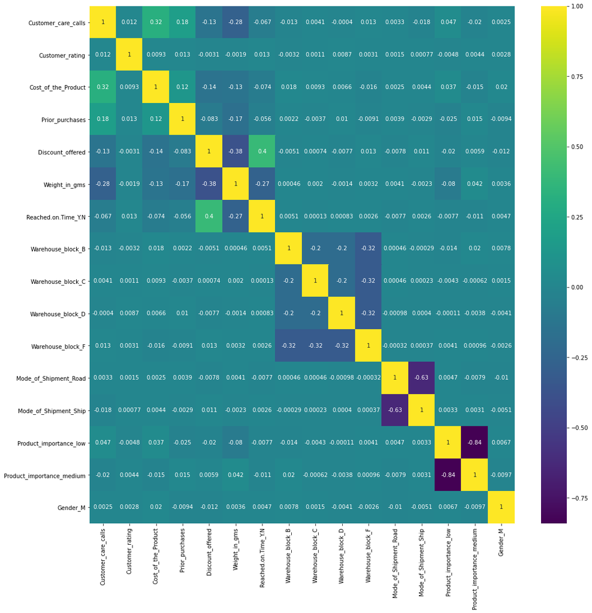

```python
plt.figure(figsize=(17,17))

sns.heatmap(df.corr(), annot=True, cmap="viridis")
plt.show()
```

### Model Building

```python
y = df['Reached.on.Time_Y.N']
```

```python
X = df.drop('Reached.on.Time_Y.N', axis=1)
```

```python
print(X.columns)
```

```
Index(['Customer_care_calls', 'Customer_rating', 'Cost_of_the_Product',
       'Prior_purchases', 'Discount_offered', 'Weight_in_gms',
       'Warehouse_block_B', 'Warehouse_block_C', 'Warehouse_block_D',
       'Warehouse_block_F', 'Mode_of_Shipment_Road', 'Mode_of_Shipment_Ship',
       'Product_importance_low', 'Product_importance_medium', 'Gender_M'],
      dtype='object')
```

#### Splitting the data into training and test set 70:30

```python
from sklearn.model_selection import train_test_split
```

```python
X_train, X_test, y_train, y_test = train_test_split(X, y, test_size=0.3, random_state=42, stratify=y)
```

```python
X.describe().T
```

|  | count | mean | std | min | 25% | 50% | 75% | max |
| --- | --- | --- | --- | --- | --- | --- | --- | --- |
| Customer_care_calls | 10999.0 | 4.054459 | 1.141490 | 2.0 | 3.0 | 4.0 | 5.0 | 7.0 |
| Customer_rating | 10999.0 | 2.990545 | 1.413603 | 1.0 | 2.0 | 3.0 | 4.0 | 5.0 |
| Cost_of_the_Product | 10999.0 | 210.196836 | 48.063272 | 96.0 | 169.0 | 214.0 | 251.0 | 310.0 |
| Prior_purchases | 10999.0 | 3.567597 | 1.522860 | 2.0 | 3.0 | 3.0 | 4.0 | 10.0 |
| Discount_offered | 10999.0 | 13.373216 | 16.205527 | 1.0 | 4.0 | 7.0 | 10.0 | 65.0 |
| Weight_in_gms | 10999.0 | 3634.016729 | 1635.377251 | 1001.0 | 1839.5 | 4149.0 | 5050.0 | 7846.0 |
| Warehouse_block_B | 10999.0 | 0.166652 | 0.372681 | 0.0 | 0.0 | 0.0 | 0.0 | 1.0 |
| Warehouse_block_C | 10999.0 | 0.166652 | 0.372681 | 0.0 | 0.0 | 0.0 | 0.0 | 1.0 |
| Warehouse_block_D | 10999.0 | 0.166742 | 0.372763 | 0.0 | 0.0 | 0.0 | 0.0 | 1.0 |
| Warehouse_block_F | 10999.0 | 0.333303 | 0.471415 | 0.0 | 0.0 | 0.0 | 1.0 | 1.0 |
| Mode_of_Shipment_Road | 10999.0 | 0.160015 | 0.366636 | 0.0 | 0.0 | 0.0 | 0.0 | 1.0 |
| Mode_of_Shipment_Ship | 10999.0 | 0.678425 | 0.467102 | 0.0 | 0.0 | 1.0 | 1.0 | 1.0 |
| Product_importance_low | 10999.0 | 0.481589 | 0.499684 | 0.0 | 0.0 | 0.0 | 1.0 | 1.0 |
| Product_importance_medium | 10999.0 | 0.432221 | 0.495407 | 0.0 | 0.0 | 0.0 | 1.0 | 1.0 |
| Gender_M | 10999.0 | 0.495863 | 0.500006 | 0.0 | 0.0 | 0.0 | 1.0 | 1.0 |

As we can see that the features are not on same scale and it will be difficult for the model. Inorder to avoid that let us apply scaling on the features so that they all will be on a same scale.

#### Scalling

```python
from sklearn.preprocessing import MinMaxScaler
```

```python
scaler = MinMaxScaler()
```

```python
X_train = scaler.fit_transform(X_train)
```

```python
X_test = scaler.transform(X_test)
```

```python
X_train = pd.DataFrame(X_train, columns = X.columns)
X_test = pd.DataFrame(X_test, columns = X.columns)
X_train.head()
```

|  | Customer_care_calls | Customer_rating | Cost_of_the_Product | Prior_purchases | Discount_offered | Weight_in_gms | Warehouse_block_B | Warehouse_block_C | Warehouse_block_D | Warehouse_block_F | Mode_of_Shipment_Road | Mode_of_Shipment_Ship | Product_importance_low | Product_importance_medium | Gender_M |
| --- | --- | --- | --- | --- | --- | --- | --- | --- | --- | --- | --- | --- | --- | --- | --- |
| 0 | 0.2 | 0.0 | 0.654206 | 0.125 | 0.109375 | 0.634039 | 0.0 | 0.0 | 0.0 | 0.0 | 1.0 | 0.0 | 0.0 | 1.0 | 0.0 |
| 1 | 0.2 | 1.0 | 0.785047 | 0.000 | 0.500000 | 0.149014 | 0.0 | 1.0 | 0.0 | 0.0 | 0.0 | 1.0 | 0.0 | 1.0 | 1.0 |
| 2 | 0.4 | 0.0 | 0.285047 | 0.000 | 0.062500 | 0.678744 | 0.0 | 0.0 | 0.0 | 0.0 | 0.0 | 1.0 | 0.0 | 1.0 | 0.0 |
| 3 | 0.6 | 1.0 | 0.411215 | 0.125 | 0.093750 | 0.546530 | 1.0 | 0.0 | 0.0 | 0.0 | 0.0 | 1.0 | 0.0 | 1.0 | 1.0 |
| 4 | 0.2 | 0.5 | 0.294393 | 0.125 | 0.031250 | 0.617823 | 0.0 | 0.0 | 0.0 | 0.0 | 0.0 | 1.0 | 1.0 | 0.0 | 1.0 |

```python
X_train.describe().T
```

|  | count | mean | std | min | 25% | 50% | 75% | max |
| --- | --- | --- | --- | --- | --- | --- | --- | --- |
| Customer_care_calls | 7699.0 | 0.409326 | 0.226903 | 0.0 | 0.200000 | 0.400000 | 0.600000 | 1.0 |
| Customer_rating | 7699.0 | 0.498344 | 0.353974 | 0.0 | 0.250000 | 0.500000 | 0.750000 | 1.0 |
| Cost_of_the_Product | 7699.0 | 0.532491 | 0.223984 | 0.0 | 0.345794 | 0.551402 | 0.724299 | 1.0 |
| Prior_purchases | 7699.0 | 0.196909 | 0.190457 | 0.0 | 0.125000 | 0.125000 | 0.250000 | 1.0 |
| Discount_offered | 7699.0 | 0.193763 | 0.252787 | 0.0 | 0.046875 | 0.093750 | 0.140625 | 1.0 |
| Weight_in_gms | 7699.0 | 0.384599 | 0.238069 | 0.0 | 0.123594 | 0.458145 | 0.589920 | 1.0 |
| Warehouse_block_B | 7699.0 | 0.169503 | 0.375220 | 0.0 | 0.000000 | 0.000000 | 0.000000 | 1.0 |
| Warehouse_block_C | 7699.0 | 0.164567 | 0.370813 | 0.0 | 0.000000 | 0.000000 | 0.000000 | 1.0 |
| Warehouse_block_D | 7699.0 | 0.166125 | 0.372217 | 0.0 | 0.000000 | 0.000000 | 0.000000 | 1.0 |
| Warehouse_block_F | 7699.0 | 0.332121 | 0.471005 | 0.0 | 0.000000 | 0.000000 | 1.000000 | 1.0 |
| Mode_of_Shipment_Road | 7699.0 | 0.156254 | 0.363120 | 0.0 | 0.000000 | 0.000000 | 0.000000 | 1.0 |
| Mode_of_Shipment_Ship | 7699.0 | 0.682556 | 0.465512 | 0.0 | 0.000000 | 1.000000 | 1.000000 | 1.0 |
| Product_importance_low | 7699.0 | 0.479413 | 0.499608 | 0.0 | 0.000000 | 0.000000 | 1.000000 | 1.0 |
| Product_importance_medium | 7699.0 | 0.432913 | 0.495511 | 0.0 | 0.000000 | 0.000000 | 1.000000 | 1.0 |
| Gender_M | 7699.0 | 0.489544 | 0.499923 | 0.0 | 0.000000 | 0.000000 | 1.000000 | 1.0 |

#### Decision Tree Classifier

```python
from sklearn.tree import DecisionTreeClassifier
```

```python
from sklearn.metrics import classification_report, accuracy_score, confusion_matrix
```

```python
tree = DecisionTreeClassifier(min_samples_leaf=20)
```

```python
tree.fit(X_train, y_train)
```

```
DecisionTreeClassifier(min_samples_leaf=20)
```

```python
tree.score(X_test, y_test)
```

```
0.6524242424242425
```

```python
tree.score(X_train, y_train)
```

```
0.7594492791271594
```

```python
y_pred = tree.predict(X_test)
```

```python
tree_accuracy = accuracy_score(y_test, y_pred)

print("Accuracy: {:.2f}%".format(tree_accuracy*100))
print("--"*60)

print(classification_report(y_test, y_pred))
```

```
Accuracy: 65.24%
------------------------------------------------------------------------------------------------------------------------
              precision    recall  f1-score   support

           0       0.56      0.63      0.60      1331
           1       0.73      0.66      0.70      1969

    accuracy                           0.65      3300
   macro avg       0.65      0.65      0.65      3300
weighted avg       0.66      0.65      0.66      3300
```

```python
confusion_matrix(y_test, y_pred)
```

```
array([[ 844,  487],
       [ 660, 1309]], dtype=int64)
```

```
Confusion Matrix For Decision Tree Classifier
```

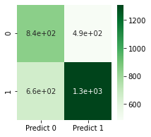

```python
print("Confusion Matrix For Decision Tree Classifier")
cm = confusion_matrix(y_test, y_pred, labels=[0,1])

df_cm = pd.DataFrame(cm, index = [i for i in [0,1]],
                  columns = [i for i in ["Predict 0", "Predict 1"]])
plt.figure(figsize = (3,3))
sns.heatmap(df_cm, annot=True, cmap = 'Greens')
plt.show()
```

```python
# Adding the second results to dataframe
results = pd.DataFrame({'Algorithm':['Decision Tree Classifier'], 'Accuracy': tree_accuracy}, index={1})
results = results[['Algorithm','Accuracy']]
results
```

|  | Algorithm | Accuracy |
| --- | --- | --- |
| 1 | Decision Tree Classifier | 0.652424 |

#### K Fold for Decision Tree

```python
from sklearn.model_selection import cross_val_score
from sklearn.model_selection import KFold
from sklearn.model_selection import cross_val_predict
```

```python
k = 20
kfold = KFold(n_splits=k, random_state=20, shuffle=True)
k_results = cross_val_score(tree, X, y, cv = kfold)
accuracy = np.mean(abs(k_results))
accuracy
```

```
0.649240105977811
```

```python
# Adding the second results to dataframe
results_2 = pd.DataFrame({'Algorithm':['K Fold for Decision Tree'], 'Accuracy': accuracy}, index={2})
results = pd.concat([results, results_2])
results = results[['Algorithm','Accuracy']]
results
```

|  | Algorithm | Accuracy |
| --- | --- | --- |
| 1 | Decision Tree Classifier | 0.652424 |
| 2 | K Fold for Decision Tree | 0.649240 |

#### Random Forest Classifier

```python
from sklearn.ensemble import RandomForestClassifier
```

```python
forest = RandomForestClassifier(min_samples_leaf=20)
```

```python
forest.fit(X_train, y_train)
```

```
RandomForestClassifier(min_samples_leaf=20)
```

```python
forest.score(X_test, y_test)
```

```
0.6706060606060606
```

```python
forest.score(X_train, y_train)
```

```
0.7508767372386024
```

```python
y_pred = forest.predict(X_test)
```

```python
forest_accuracy = accuracy_score(y_test, y_pred)

print("Accuracy: {:.2f}%".format(forest_accuracy*100))
print("--"*60)

print(classification_report(y_test, y_pred))
```

```
Accuracy: 67.06%
------------------------------------------------------------------------------------------------------------------------
              precision    recall  f1-score   support

           0       0.56      0.86      0.68      1331
           1       0.86      0.54      0.66      1969

    accuracy                           0.67      3300
   macro avg       0.71      0.70      0.67      3300
weighted avg       0.74      0.67      0.67      3300
```

```python
confusion_matrix(y_test, y_pred)
```

```
array([[1151,  180],
       [ 907, 1062]], dtype=int64)
```

```
Confusion Matrix For Random Forest Classifier
```

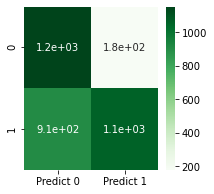

```python
print("Confusion Matrix For Random Forest Classifier")
cm = confusion_matrix(y_test, y_pred, labels=[0,1])

df_cm = pd.DataFrame(cm, index = [i for i in [0,1]],
                  columns = [i for i in ["Predict 0", "Predict 1"]])
plt.figure(figsize = (3,3))
sns.heatmap(df_cm, annot=True, cmap = 'Greens')
plt.show()
```

```python
# Adding the second results to dataframe
results_2 = pd.DataFrame({'Algorithm':['Random Forest Classifer'], 'Accuracy': forest_accuracy}, index={3})
results = pd.concat([results, results_2])
results = results[['Algorithm','Accuracy']]
results
```

|  | Algorithm | Accuracy |
| --- | --- | --- |
| 1 | Decision Tree Classifier | 0.652424 |
| 2 | K Fold for Decision Tree | 0.649240 |
| 3 | Random Forest Classifer | 0.670606 |

#### K Fold for Random Forest

```python
k = 20
kfold = KFold(n_splits=k, random_state=20, shuffle=True)
k_results = cross_val_score(forest, X, y, cv = kfold)
accuracy = np.mean(abs(k_results))
accuracy
```

```
0.6774230832919358
```

```python
# Adding the second results to dataframe
results_2 = pd.DataFrame({'Algorithm':['K Fold Random Forest Classifer'], 'Accuracy': accuracy}, index={4})
results = pd.concat([results, results_2])
results = results[['Algorithm','Accuracy']]
results
```

|  | Algorithm | Accuracy |
| --- | --- | --- |
| 1 | Decision Tree Classifier | 0.652424 |
| 2 | K Fold for Decision Tree | 0.649240 |
| 3 | Random Forest Classifer | 0.670606 |
| 4 | K Fold Random Forest Classifer | 0.677423 |

#### Gradient Boosting Classifier

```python
from sklearn.ensemble import GradientBoostingClassifier
```

```python
gbc = GradientBoostingClassifier()
```

```python
gbc.fit(X_train, y_train)
```

```
GradientBoostingClassifier()
```

```python
gbc.score(X_test, y_test)
```

```
0.6742424242424242
```

```python
gbc.score(X_train, y_train)
```

```
0.7176256656708664
```

```python
y_pred = gbc.predict(X_test)

gbc_accuracy = accuracy_score(y_test, y_pred)

print("Accuracy: {:.2f}%".format(gbc_accuracy*100))
print("--"*60)

print(classification_report(y_test, y_pred))
```

```
Accuracy: 67.42%
------------------------------------------------------------------------------------------------------------------------
              precision    recall  f1-score   support

           0       0.56      0.91      0.69      1331
           1       0.89      0.52      0.65      1969

    accuracy                           0.67      3300
   macro avg       0.72      0.71      0.67      3300
weighted avg       0.76      0.67      0.67      3300
```

```python
confusion_matrix(y_test, y_pred)
```

```
array([[1205,  126],
       [ 949, 1020]], dtype=int64)
```

```
Confusion Matrix For Gradient Boosting Classifier
```

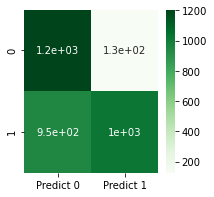

```python
print("Confusion Matrix For Gradient Boosting Classifier")
cm = confusion_matrix(y_test, y_pred, labels=[0,1])

df_cm = pd.DataFrame(cm, index = [i for i in [0,1]],
                  columns = [i for i in ["Predict 0", "Predict 1"]])
plt.figure(figsize = (3,3))
sns.heatmap(df_cm, annot=True, cmap = 'Greens')
plt.show()
```

```python
# Adding the second results to dataframe
results_2 = pd.DataFrame({'Algorithm':['Gradient Boost Classifier'], 'Accuracy': gbc_accuracy}, index={5})
results = pd.concat([results, results_2])
results = results[['Algorithm','Accuracy']]
results
```

|  | Algorithm | Accuracy |
| --- | --- | --- |
| 1 | Decision Tree Classifier | 0.652424 |
| 2 | K Fold for Decision Tree | 0.649240 |
| 3 | Random Forest Classifer | 0.670606 |
| 4 | K Fold Random Forest Classifer | 0.677423 |
| 5 | Gradient Boost Classifier | 0.674242 |

#### K Fold for Gradient Boost

```python
k = 20
kfold = KFold(n_splits=k, random_state=20, shuffle=True)
k_results = cross_val_score(gbc, X, y, cv = kfold)
accuracy = np.mean(abs(k_results))
accuracy
```

```
0.6817897002815035
```

```python
y_pred_kfold = cross_val_predict(gbc, X, y, cv=kfold)

gbc_accuracy_kfold = accuracy_score(y, y_pred_kfold)

print("Accuracy: {:.2f}%".format(gbc_accuracy_kfold*100))
print("--"*60)

print(classification_report(y, y_pred_kfold))
```

```
Accuracy: 68.17%
------------------------------------------------------------------------------------------------------------------------
              precision    recall  f1-score   support

           0       0.57      0.90      0.70      4436
           1       0.89      0.53      0.67      6563

    accuracy                           0.68     10999
   macro avg       0.73      0.72      0.68     10999
weighted avg       0.76      0.68      0.68     10999
```

```python
# Adding the second results to dataframe
results_2 = pd.DataFrame({'Algorithm':['K Fold Gradient Boost Classifier'], 'Accuracy': accuracy}, index={6})
results = pd.concat([results, results_2])
results = results[['Algorithm','Accuracy']]
results
```

|  | Algorithm | Accuracy |
| --- | --- | --- |
| 1 | Decision Tree Classifier | 0.652424 |
| 2 | K Fold for Decision Tree | 0.649240 |
| 3 | Random Forest Classifer | 0.670606 |
| 4 | K Fold Random Forest Classifer | 0.677423 |
| 5 | Gradient Boost Classifier | 0.674242 |
| 6 | K Fold Gradient Boost Classifier | 0.681790 |

#### Logistic Regression

```python
from sklearn.linear_model import LogisticRegression
```

```python
logreg = LogisticRegression().fit(X_train, y_train)
```

```python
logreg.score(X_test, y_test)
```

```
0.6381818181818182
```

```python
logreg.score(X_train, y_train)
```

```
0.641641771658657
```

```python
logreg_y = logreg.predict(X_test)
```

```python
y_pred = logreg.predict(X_test)

log_accuracy = accuracy_score(y_test, y_pred)

print("Accuracy: {:.2f}%".format(log_accuracy*100))
print("--"*60)

print(classification_report(y_test, y_pred))
```

```
Accuracy: 63.82%
------------------------------------------------------------------------------------------------------------------------
              precision    recall  f1-score   support

           0       0.55      0.58      0.57      1331
           1       0.71      0.67      0.69      1969

    accuracy                           0.64      3300
   macro avg       0.63      0.63      0.63      3300
weighted avg       0.64      0.64      0.64      3300
```

```python
confusion_matrix(y_test, logreg_y)
```

```
array([[ 778,  553],
       [ 641, 1328]], dtype=int64)
```

```python
pd.crosstab(y_test, logreg_y, rownames = ['Actual'], colnames =['Predicted'], margins = True)
```

| Predicted Actual | 0 | 1 | All |
| --- | --- | --- | --- |
| 0 | 778 | 553 | 1331 |
| 1 | 641 | 1328 | 1969 |
| All | 1419 | 1881 | 3300 |

```python
# Adding the second results to dataframe
results_2 = pd.DataFrame({'Algorithm':['Logistic Regression'], 'Accuracy': log_accuracy}, index={7})
results = pd.concat([results, results_2])
results = results[['Algorithm','Accuracy']]
results
```

|  | Algorithm | Accuracy |
| --- | --- | --- |
| 1 | Decision Tree Classifier | 0.652424 |
| 2 | K Fold for Decision Tree | 0.649240 |
| 3 | Random Forest Classifer | 0.670606 |
| 4 | K Fold Random Forest Classifer | 0.677423 |
| 5 | Gradient Boost Classifier | 0.674242 |
| 6 | K Fold Gradient Boost Classifier | 0.681790 |
| 7 | Logistic Regression | 0.638182 |

#### KNN Classifier

```python
from sklearn.neighbors import KNeighborsClassifier
```

```python
knn = KNeighborsClassifier(n_neighbors=9).fit(X_train, y_train)
```

```python
knn.score(X_train, y_train)
```

```
0.7248993375763086
```

```python
knn.score(X_test, y_test)
```

```
0.6324242424242424
```

```python
y_pred = knn.predict(X_test)
```

```python
y_pred = knn.predict(X_test)

knn_accuracy = accuracy_score(y_test, y_pred)

print("Accuracy: {:.2f}%".format(knn_accuracy*100))
print("--"*60)

print(classification_report(y_test, y_pred))
```

```
Accuracy: 63.24%
------------------------------------------------------------------------------------------------------------------------
              precision    recall  f1-score   support

           0       0.54      0.59      0.56      1331
           1       0.70      0.66      0.68      1969

    accuracy                           0.63      3300
   macro avg       0.62      0.63      0.62      3300
weighted avg       0.64      0.63      0.63      3300
```

```python
pd.crosstab(y_test, y_pred, rownames = ['Actual'], colnames =['Predicted'], margins = True)
```

| Predicted Actual | 0 | 1 | All |
| --- | --- | --- | --- |
| 0 | 781 | 550 | 1331 |
| 1 | 663 | 1306 | 1969 |
| All | 1444 | 1856 | 3300 |

```python
# Adding the second results to dataframe
results_2 = pd.DataFrame({'Algorithm':['KNN Classifier'], 'Accuracy': knn_accuracy}, index={8})
results = pd.concat([results, results_2])
results = results[['Algorithm','Accuracy']]
results
```

|  | Algorithm | Accuracy |
| --- | --- | --- |
| 1 | Decision Tree Classifier | 0.652424 |
| 2 | K Fold for Decision Tree | 0.649240 |
| 3 | Random Forest Classifer | 0.670606 |
| 4 | K Fold Random Forest Classifer | 0.677423 |
| 5 | Gradient Boost Classifier | 0.674242 |
| 6 | K Fold Gradient Boost Classifier | 0.681790 |
| 7 | Logistic Regression | 0.638182 |
| 8 | KNN Classifier | 0.632424 |

#### Sorting the Models based on their Accuracies

```python
results.sort_values(by='Accuracy', ascending=False)
```

|  | Algorithm | Accuracy |
| --- | --- | --- |
| 6 | K Fold Gradient Boost Classifier | 0.681790 |
| 4 | K Fold Random Forest Classifer | 0.677423 |
| 5 | Gradient Boost Classifier | 0.674242 |
| 3 | Random Forest Classifer | 0.670606 |
| 1 | Decision Tree Classifier | 0.652424 |
| 2 | K Fold for Decision Tree | 0.649240 |
| 7 | Logistic Regression | 0.638182 |
| 8 | KNN Classifier | 0.632424 |

From the table we can see that all the models are giving less score on this Dataset. Out of all the Models we are getting better score from the Gradient Boosting Classifier followed by Random Forest Classifier and Decision Tree. Let us do some hyper parameter tuning for those models to see if they will perform any better.

#### Checking Gradient Boosting Classifier

```python
gbc = GradientBoostingClassifier(n_estimators=70,
                                 max_depth = 4,
                                 min_samples_split=3,
                                 criterion='mse')
```

```
GradientBoostingClassifier(criterion='mse', max_depth=4, min_samples_split=3,
                           n_estimators=70)
------------------------------------------------------------------------------------------------------------------------
Test Data Accuracy Score: 67.94%
------------------------------------------------------------------------------------------------------------------------
Train Data Accuracy Score: 72.62%
------------------------------------------------------------------------------------------------------------------------
Accuracy: 0.6793939393939394
------------------------------------------------------------------------------------------------------------------------
Classification Report:
              precision    recall  f1-score   support

           0       0.56      0.90      0.69      1331
           1       0.89      0.53      0.66      1969

    accuracy                           0.68      3300
   macro avg       0.73      0.72      0.68      3300
weighted avg       0.76      0.68      0.68      3300

------------------------------------------------------------------------------------------------------------------------
Confusion Matrix:
[[1202  129]
 [ 929 1040]]
------------------------------------------------------------------------------------------------------------------------
Confusion Matrix For Gradient Boosting Classifier:
```

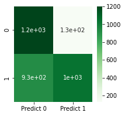

```python
#Fitting the training model
gbc.fit(X_train, y_train)
print(gbc.fit(X_train, y_train))
print("--"*60)


#Checking the Testing accuracy score
gbc.score(X_test, y_test)
print("Test Data Accuracy Score: {:.2f}%".format(gbc.score(X_test, y_test)*100))
print("--"*60)

#Checking the testing accuracy score
gbc.score(X_train, y_train)
print("Train Data Accuracy Score: {:.2f}%".format(gbc.score(X_train, y_train)*100))
print("--"*60)

#Predicting test data values
y_pred = gbc.predict(X_test)

#Checking the accuracy score
gbc_accuracy = accuracy_score(y_test, y_pred)

#Printing Accuracy score
print("Accuracy: {}".format(gbc_accuracy))
print("--"*60)

#Printing Classification Report
print("Classification Report:")
print(classification_report(y_test, y_pred))
print("--"*60)

#Printing Confusion Matrix
print("Confusion Matrix:")
print(confusion_matrix(y_test, y_pred))
print("--"*60)

#Printing Heat Map for confusion Matrix
print("Confusion Matrix For Gradient Boosting Classifier:")
cm = confusion_matrix(y_test, y_pred, labels=[0,1])
df_cm = pd.DataFrame(cm, index = [i for i in [0,1]],
                  columns = [i for i in ["Predict 0", "Predict 1"]])
plt.figure(figsize = (3,3))
sns.heatmap(df_cm, annot=True, cmap = 'Greens')
plt.show()
```

After some Manual Hyperparameter tuning we are able to achieve a score of nealy 68% accuracy. But in this Dataset along with the accuracy we need to take Recall Metric into consideration as we are more keen to look at the True Positive Rate in this dataset. As the Recall value of this model is very low, we may not consider this model for prediction.

#### Checking Decision Tree

Here we are considering Decision Tree over Random Forest because this tree is giving us better Recall score than the random forest. Hence we are considering Decision Tree Classifier for our further model building.

```python
tree = DecisionTreeClassifier(min_samples_leaf=20)

tree.fit(X_train, y_train)
print(tree.fit(X_train, y_train))
print("--"*60)

print("Test Data Score: {:.2f}%".format(tree.score(X_test, y_test)*100))
print("--"*60)

print("Training Data Score: {:.2f}%".format(tree.score(X_train, y_train)*100))
print("--"*60)

y_pred = tree.predict(X_test)
tree_accuracy = accuracy_score(y_test, y_pred)
print("Accuracy: {:.2f}%".format(tree_accuracy))
print("--"*60)

print("Classification Report:")
print(classification_report(y_test, y_pred))
print("--"*60)

print("Confusion Matrix: ")
print(confusion_matrix(y_test, y_pred))
print("--"*60)

pd.crosstab(y_test, y_pred, rownames = ['Actual'], colnames =['Predicted'], margins = True)
```

```
DecisionTreeClassifier(min_samples_leaf=20)
------------------------------------------------------------------------------------------------------------------------
Test Data Score: 65.24%
------------------------------------------------------------------------------------------------------------------------
Training Data Score: 75.94%
------------------------------------------------------------------------------------------------------------------------
Accuracy: 0.65%
------------------------------------------------------------------------------------------------------------------------
Classification Report:
              precision    recall  f1-score   support

           0       0.56      0.63      0.60      1331
           1       0.73      0.66      0.70      1969

    accuracy                           0.65      3300
   macro avg       0.65      0.65      0.65      3300
weighted avg       0.66      0.65      0.66      3300

------------------------------------------------------------------------------------------------------------------------
Confusion Matrix:
[[ 844  487]
 [ 660 1309]]
------------------------------------------------------------------------------------------------------------------------
```

| Predicted Actual | 0 | 1 | All |
| --- | --- | --- | --- |
| 0 | 844 | 487 | 1331 |
| 1 | 660 | 1309 | 1969 |
| All | 1504 | 1796 | 3300 |

#### Shuffle Fold for Decision Tree

```python
from sklearn.model_selection import cross_val_predict
from sklearn.metrics import log_loss

k = 25
kfold = KFold(n_splits=k, random_state=50, shuffle=True)
k_results = cross_val_score(tree, X, y, cv = kfold)
accuracy = np.mean(abs(k_results))

print("Accuracy for K Fold: {:.2f}%".format(accuracy*100))
print("--"*60)

y_pred = cross_val_predict(tree, X, y, cv=kfold)
print("Classification Report:")
print(classification_report(y, y_pred))
print("--"*60)

print("Confusion Matirx:")
print(confusion_matrix(y,y_pred))
print("--"*60)

print("Log Loss: ")
print(log_loss(y,y_pred))
print("--"*60)

print("Cross Tab for the Confusion Matrix")
pd.crosstab(y, y_pred, rownames = ['Actual'], colnames =['Predicted'], margins = True)
```

```
Accuracy for K Fold: 65.87%
------------------------------------------------------------------------------------------------------------------------
Classification Report:
              precision    recall  f1-score   support

           0       0.57      0.63      0.60      4436
           1       0.73      0.68      0.70      6563

    accuracy                           0.66     10999
   macro avg       0.65      0.65      0.65     10999
weighted avg       0.67      0.66      0.66     10999

------------------------------------------------------------------------------------------------------------------------
Confusion Matirx:
[[2805 1631]
 [2121 4442]]
------------------------------------------------------------------------------------------------------------------------
Log Loss:
11.782052293582463
------------------------------------------------------------------------------------------------------------------------
Cross Tab for the Confusion Matrix
```

| Predicted Actual | 0 | 1 | All |
| --- | --- | --- | --- |
| 0 | 2805 | 1631 | 4436 |
| 1 | 2121 | 4442 | 6563 |
| All | 4926 | 6073 | 10999 |

We can see that using Shuffle Cross Validation we got more accuracy more than previous score and also the Recall value of Delayed Deliveries also increased. I want to take Recall value of 1 into evaluation matrix for this Dataset because I want to know how many products are actually getting delayed to the products that we predicted to be delayed.  
Out of all the deliveries, I wnt to know how many products are actually getting delayed and to the products that we predicted to be delayed.  
I want to see if the model is predicted the delayed status properly or not.  
Hence we can consider this model for predictions.

```python
tree.feature_importances_
```

```
array([0.0205281 , 0.01924889, 0.08603067, 0.06527916, 0.61802127,
       0.15284792, 0.00144178, 0.        , 0.00191431, 0.00324643,
       0.00338734, 0.00891028, 0.00418231, 0.00662415, 0.00833739])
```

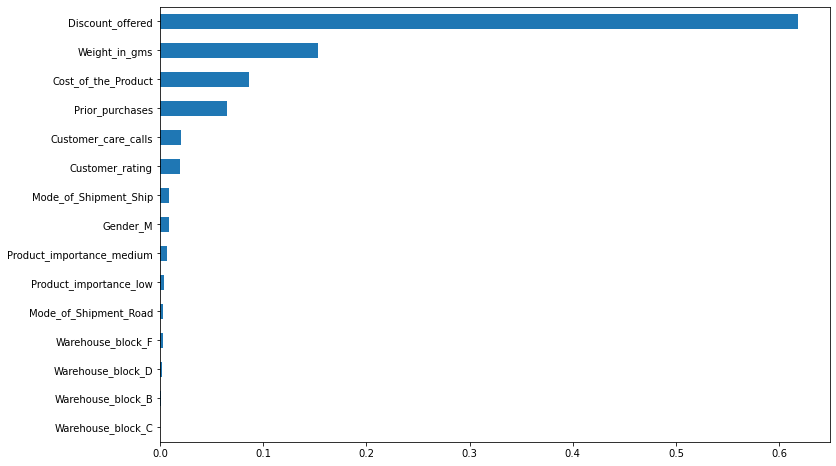

```python
#plot graph of feature importances for better visualization

plt.figure(figsize = (12,8))
feat_importances = pd.Series(tree.feature_importances_ , index=X.columns)
feat_importances.nlargest(15).sort_values(ascending = True).plot(kind='barh')
plt.show()
```

```python
feat_imp =  pd.DataFrame(tree.feature_importances_ , index=X.columns, columns=['Importance'])
feat_imp.sort_values(by='Importance', ascending=False)
```

|  | Importance |
| --- | --- |
| Discount_offered | 0.618021 |
| Weight_in_gms | 0.152848 |
| Cost_of_the_Product | 0.086031 |
| Prior_purchases | 0.065279 |
| Customer_care_calls | 0.020528 |
| Customer_rating | 0.019249 |
| Mode_of_Shipment_Ship | 0.008910 |
| Gender_M | 0.008337 |
| Product_importance_medium | 0.006624 |
| Product_importance_low | 0.004182 |
| Mode_of_Shipment_Road | 0.003387 |
| Warehouse_block_F | 0.003246 |
| Warehouse_block_D | 0.001914 |
| Warehouse_block_B | 0.001442 |
| Warehouse_block_C | 0.000000 |

- **Discount_offered**
- **Weight_in_gms**
- **Cost_of_the_Product**
- **Prior_purchases**
- **Customer_care_calls**
- **Customer_rating**

### Prediction

```python
X.columns
```

```
Index(['Customer_care_calls', 'Customer_rating', 'Cost_of_the_Product',
       'Prior_purchases', 'Discount_offered', 'Weight_in_gms',
       'Warehouse_block_B', 'Warehouse_block_C', 'Warehouse_block_D',
       'Warehouse_block_F', 'Mode_of_Shipment_Road', 'Mode_of_Shipment_Ship',
       'Product_importance_low', 'Product_importance_medium', 'Gender_M'],
      dtype='object')
```

```python
pd.set_option("display.max_columns", None)
X.head(1)
```

|  | Customer_care_calls | Customer_rating | Cost_of_the_Product | Prior_purchases | Discount_offered | Weight_in_gms | Warehouse_block_B | Warehouse_block_C | Warehouse_block_D | Warehouse_block_F | Mode_of_Shipment_Road | Mode_of_Shipment_Ship | Product_importance_low | Product_importance_medium | Gender_M |
| --- | --- | --- | --- | --- | --- | --- | --- | --- | --- | --- | --- | --- | --- | --- | --- |
| 0 | 4 | 2 | 177 | 3 | 44 | 1233 | 0 | 0 | 1 | 0 | 0 | 0 | 1 | 0 | 0 |

```python
data = pd.DataFrame({'Customer_care_calls': [2, 7],
                    'Customer_rating': [4, 5],
                    'Cost_of_the_Product': [150, 350],
                    'Prior_purchases': [2, 2],
                    'Discount_offered': [50, 9],
                    'Weight_in_gms': [3000, 5000],
                    'Warehouse_block_B': [0,0],
                    'Warehouse_block_C': [1,0],
                    'Warehouse_block_D': [0,0],
                    'Warehouse_block_F': [0,1],
                    'Mode_of_Shipment_Road': [1,0],
                    'Mode_of_Shipment_Ship': [0,0],
                    'Product_importance_low': [0,0],
                    'Product_importance_medium': [1,0],
                    'Gender_M': [1,0]
                    })
data
```

|  | Customer_care_calls | Customer_rating | Cost_of_the_Product | Prior_purchases | Discount_offered | Weight_in_gms | Warehouse_block_B | Warehouse_block_C | Warehouse_block_D | Warehouse_block_F | Mode_of_Shipment_Road | Mode_of_Shipment_Ship | Product_importance_low | Product_importance_medium | Gender_M |
| --- | --- | --- | --- | --- | --- | --- | --- | --- | --- | --- | --- | --- | --- | --- | --- |
| 0 | 2 | 4 | 150 | 2 | 50 | 3000 | 0 | 1 | 0 | 0 | 1 | 0 | 0 | 1 | 1 |
| 1 | 7 | 5 | 350 | 2 | 9 | 5000 | 0 | 0 | 0 | 1 | 0 | 0 | 0 | 0 | 0 |

```python
data = scaler.transform(data)
```

```python
tree.predict(data)
```

```
array([1, 0], dtype=int64)
```